# Analysis of the Lunar Gravity Dataset

Author: Weigang Liang  
This is intended to provide a brief introduction to the lunar gravity dataset and how it can be analyzed using Markov chain Monte Carlo.  
To download the gravity and topography data: https://drive.google.com/drive/folders/1e7Zil4MM9YN9_3rgnY-uGIFQ6x28YN97?usp=sharing

```python
#importing the required modules and defining constants
import pyshtools

import matplotlib.pyplot as plt
#from pyshtools import constant, can't do for Mars+Venus
import numpy as np
import pandas as pd

a = 1738000
gm = 4902.80011526323e9
```

```python
#we are using spherical harmonics (~time-series analysis), so we need a resolution parameter

lmax_calc = 150
```

```python
#extracting the necessary data

clm0 = pyshtools.SHGravCoeffs.from_file('gggrx_1200a_sha.tab.txt', errors=True, header_units='km',lmax=lmax_calc)
shape = pyshtools.SHCoeffs.from_file('MoonTopo2600p.shape.sh',lmax=lmax_calc)
```

```python
#basic data cleaning and pre-processing. Actual data cleaning/pre-processing takes 10x more lines (see mare_fill.py)

interface0 = shape.to_array()
bc = pyshtools.SHGravCoeffs.from_shape(shape, rho=2500, gm=gm, lmax=lmax_calc,nmax=9)#3100
bc2 = bc.change_ref(r0=a,gm=gm,lmax=lmax_calc)
clm0 = clm0.change_ref(r0=a,gm=gm,lmax=lmax_calc)

clm = clm0 - bc2

cilm = clm.to_array()
cilm[0][0][0] = 1
cilm[:,1:10,:] = 0

L = np.arange(0,lmax_calc+1)
L1 = round(0.9*lmax_calc)#-25
L2 = lmax_calc

taper0 = (1-np.cos((L2-L)/(L2-L1)*np.pi))/2
taper = np.tile(taper0,(L2+1,1)).transpose()

taperf = np.zeros((2,L2+1,L2+1))
taperf[0,:,:] = taper
taperf[1,:,:] = taper

cilm[:,L1:,:] = taperf[:,L1:,:]*cilm[:,L1:,:]
```

```python
#calculating gravity

r,t,p,grav,pot = pyshtools.gravmag.MakeGravGridDH(cilm,gm,a,lmax=lmax_calc,a=a,f=0,omega=0,normal_gravity=1)
```

```python
# shifting gravity map horizontally so the lunar nearside (what we see in the night sky) is at the center

grav_moon = np.roll(grav, shift=grav.shape[1]//2, axis=1)
```

```
(-0.5, 603.5, 301.5, -0.5)
```

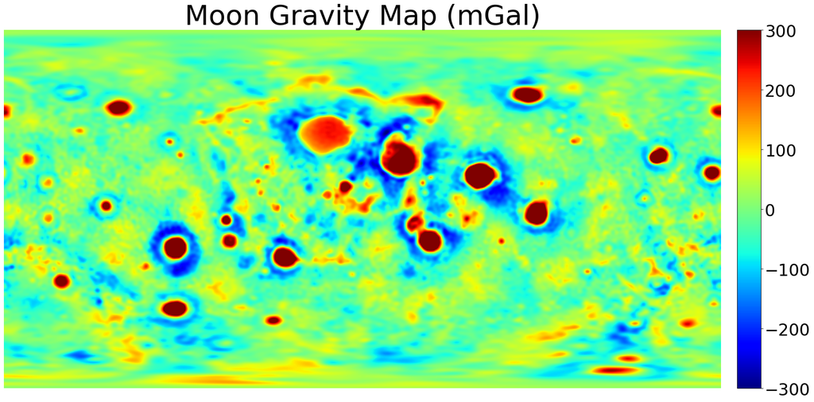

```python
#plotting gravity

plt.figure(figsize=(20,10))
ax = plt.axes([0, 0.05, 0.9, 0.9 ])
ax.set_title('Moon Gravity Map (mGal)',fontsize=50)
fig = plt.imshow(grav_moon*1e5,cmap='jet',aspect='equal',vmin=-300,vmax=300)

cax = plt.axes([0.92, 0.05, 0.03,0.9 ])
cb = plt.colorbar(fig,cax=cax)
cb.ax.tick_params(labelsize=30)


ax.axis('off')
```

The above is the lunar (Bouguer) gravity.

The circular positive (red) features are **extremely large meteor impact sites** (>3 times the size of the impact that wiped the dinosaurs).

The lines of positive (red) gravity features near the center of the map are likely remnants of when the Moon turned itself inside out (mantle overturn) **4 billion years ago**.

Below is an example of Earth's gravity (calculated using the same methods).

```
(-0.5, 963.5, 481.5, -0.5)
```

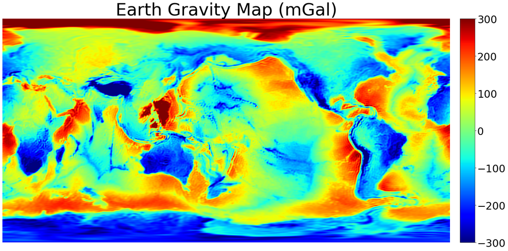

```python
earth_grav = np.load('earth_grav_demo.npy')

#plotting gravity

plt.figure(figsize=(20,10))
ax = plt.axes([0, 0.05, 0.9, 0.9 ])
ax.set_title('Earth Gravity Map (mGal)',fontsize=50)
fig = plt.imshow(earth_grav*1e5,cmap='jet',aspect='equal',vmin=-300,vmax=300)

cax = plt.axes([0.92, 0.05, 0.03,0.9 ])
cb = plt.colorbar(fig,cax=cax)
cb.ax.tick_params(labelsize=30)

ax.axis('off')
```

Asia is on the left side of the map; the Americas are on the right side.

The Earth is very warm, so signatures of meteor impacts disappear very quickly.

Instead, we see examples of plate tectonics in this gravity map, where new plates are being created (positive red areas)

MCMC Analysis

The crux of my research revolves the lines of positive gravity on the Moon. I call them **gravity anomalies**.

A hypothesis for the anomalies are that they are magma that failed to reach the surface (example image below).

```
(-0.5, 699.5, 299.5, -0.5)
```

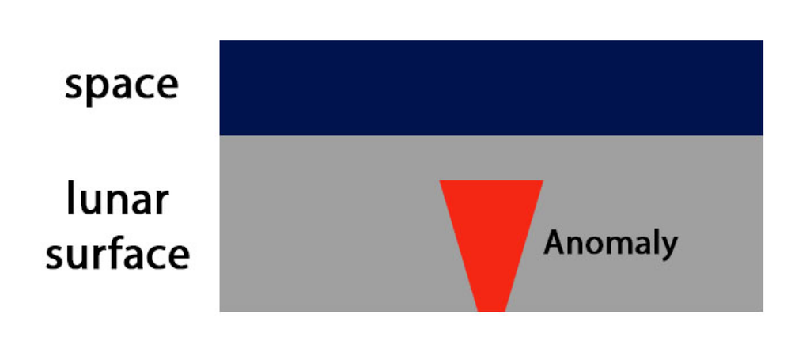

```python
from PIL import Image
import matplotlib.pyplot as plt

# Open an image file
img = Image.open('anomaly_demo.jpg')

# Display the image
plt.figure(figsize=(20,10))
ax = plt.axes([0, 0.05, 0.9, 0.9 ])
fig = plt.imshow(img)


ax.axis('off')
```

The depth and dimensions of the anomalies can be constrained using Markov chain Monte Carlo (MCMC) analysis. This involves the fitting the observed gravity of the anomalies by calculating the gravity of a proposed structure using various depths, widths, and thicknesses.

```python
iterations = 5000 #ideally >1000
# run MCMC code (see mcmc_demo.py)
from mcmc_demo import mcmc
mcmc(iterations)
```

```
Top Depth: 54.0 (42.9+11.9,-13.3) km
Width: 176.0 (196.0+51.0,-49.6) km
Thickness = 60.2 (52.2+19.5,-18.3) km
RMS: 8.43 mGal
Total runtime: 7.299 min
```

The results are presented as best-fit (mean +/- 84% and 16% percentile)

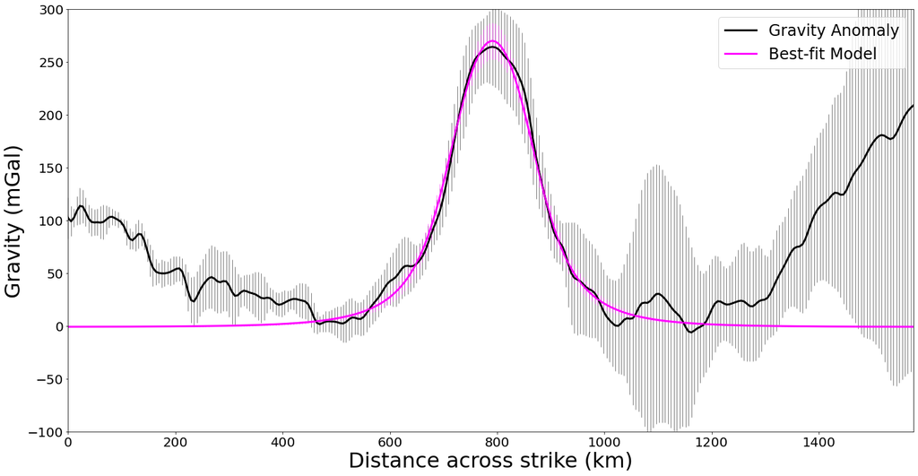

```python
#extracting best-fit parameters

df = pd.read_excel('tri.xlsx')

num = 0

# Adding data
td = float(df.iloc[num, 1][:4])*1e3
xs = float(df.iloc[num, 2][:4])*1e3
th = float(df.iloc[num, 3][:4])*1e3

#plotting MCMC best-fit model vs observed data

from plot_mcmc import plott
plott(td,xs,th)
```